# Entregable 4: Genes Diferencialmente Expresados y Análisis Funcional

Equipo 4 - Leonardo Ivan Anaya Gonzalez & Rubií Martínez Chavarría

2026-05-06

## Abstract

Se analizaron datos de RNA-seq de tejido hepático de ratón adulto para comparar la expresión génica entre ratones wild-type (WT) y el modelo Dp(16)1Yey (Dp16) de Síndrome de Down, utilizando datos del bioproyecto PRJNA1259260 (6 muestras: 3 WT y 3 Dp16, Illumina NovaSeq 6000, 150 bp paired-end, selección polyA). El control de calidad se realizó con FastQC y MultiQC, seguido de limpieza de adaptadores TruSeq3-PE con Trimmomatic (< 3% de lecturas descartadas). El pseudoalineamiento se realizó con Kallisto (>94% de alineamiento) y el alineamiento con STAR (>87% de lecturas mapeadas únicamente) usando como referencia Gencode vM24 y GRCm38. El análisis de expresión diferencial con DESeq2 identificó genes significativamente expresados entre ambas condiciones (padj < 0.05), incluyendo genes relacionados con metabolismo hepático como *Apoa4*, *Papss2* y *Ces1g*, consistentes con los hallazgos de Dunn et al. (2026). El análisis funcional con GSEA identificó términos GO enriquecidos relacionados con splicing de RNA, respuesta a quimiocinas y autofagia, sugiriendo alteraciones en el procesamiento transcriptómico asociadas a la trisomía del cromosoma 16.

## 1. Genes Diferencialmente Expresados (DEG)

```r
library(dplyr)
library(ggplot2)
library(knitr)
library(kableExtra)

res_kallisto <- read.csv("/Users/dubsirubs/Desktop/RNAseq_Equipo4/results_final/DESeq2_kallisto_results.csv", row.names=1)
res_star <- read.csv("/Users/dubsirubs/Desktop/RNAseq_Equipo4/results_final/DESeq2_STAR_results.csv", row.names=1)

# Extraer nombre del gen
res_kallisto$gene_name <- sapply(strsplit(rownames(res_kallisto), "\\|"), `[`, 6)
res_star$gene_name <- rownames(res_star)

# Genes significativos
sig_kallisto <- res_kallisto[!is.na(res_kallisto$padj) & res_kallisto$padj < 0.05, ]
sig_star <- res_star[!is.na(res_star$padj) & res_star$padj < 0.05, ]

cat("DEGs Kallisto:", nrow(sig_kallisto), "\n")
```

```
## DEGs Kallisto: 781
```

```r
cat("DEGs STAR:", nrow(sig_star), "\n")
```

```
## DEGs STAR: 363
```

### Top 20 genes más significativos (Kallisto)

```r
top20 <- head(sig_kallisto[order(sig_kallisto$padj), c("gene_name","log2FoldChange","padj")], 20)
kable(top20, caption="Top 20 DEGs - Kallisto (Dp16 vs WT)") %>%
  kable_styling(bootstrap_options=c("striped","hover","condensed"), full_width=FALSE)
```

Top 20 DEGs - Kallisto (Dp16 vs WT)

|  | gene_name | log2FoldChange | padj |
| --- | --- | --- | --- |
| ENSMUST00000025833.6&#124;ENSMUSG00000024899.7&#124;OTTMUSG00000073985.1&#124;OTTMUST00000179519.1&#124;Papss2-201&#124;Papss2&#124;3635&#124;protein_coding&#124; | Papss2 | 0.8494365 | 0 |
| ENSMUST00000034585.6&#124;ENSMUSG00000032080.6&#124;OTTMUSG00000028705.1&#124;OTTMUST00000071089.1&#124;Apoa4-201&#124;Apoa4&#124;1815&#124;protein_coding&#124; | Apoa4 | -1.3518603 | 0 |
| ENSMUST00000044602.7&#124;ENSMUSG00000057074.6&#124;OTTMUSG00000040118.1&#124;OTTMUST00000060226.1&#124;Ces1g-201&#124;Ces1g&#124;2388&#124;protein_coding&#124; | Ces1g | 1.0218202 | 0 |
| ENSMUST00000119033.7&#124;ENSMUSG00000036779.12&#124;OTTMUSG00000031334.1&#124;OTTMUST00000077628.1&#124;Tent4b-203&#124;Tent4b&#124;4624&#124;protein_coding&#124; | Tent4b | 10.3571547 | 0 |
| ENSMUST00000166783.2&#124;ENSMUSG00000032735.15&#124;OTTMUSG00000073606.1&#124;OTTMUST00000178675.1&#124;Ablim3-202&#124;Ablim3&#124;4187&#124;protein_coding&#124; | Ablim3 | -1.7699689 | 0 |
| ENSMUST00000001715.9&#124;ENSMUSG00000001665.11&#124;OTTMUSG00000031847.4&#124;OTTMUST00000078969.1&#124;Gstt3-201&#124;Gstt3&#124;1880&#124;protein_coding&#124; | Gstt3 | 1.6823903 | 0 |
| ENSMUST00000113093.4&#124;ENSMUSG00000029417.9&#124;OTTMUSG00000055603.1&#124;OTTMUST00000137614.1&#124;Cxcl9-201&#124;Cxcl9&#124;2889&#124;protein_coding&#124; | Cxcl9 | -1.8826910 | 0 |
| ENSMUST00000066912.12&#124;ENSMUSG00000054072.12&#124;OTTMUSG00000073536.1&#124;OTTMUST00000178477.1&#124;Iigp1-202&#124;Iigp1&#124;2927&#124;protein_coding&#124; | Iigp1 | -0.7440767 | 0 |
| ENSMUST00000071646.1&#124;ENSMUSG00000069456.4&#124;OTTMUSG00000027661.3&#124;OTTMUST00000068442.3&#124;Rdh16-201&#124;Rdh16&#124;3207&#124;protein_coding&#124; | Rdh16 | 1.3489838 | 0 |
| ENSMUST00000073337.7&#124;ENSMUSG00000038002.9&#124;OTTMUSG00000072572.2&#124;OTTMUST00000175631.1&#124;Cramp1l-201&#124;Cramp1l&#124;7519&#124;protein_coding&#124; | Cramp1l | -10.6372819 | 0 |
| ENSMUST00000237185.1&#124;ENSMUSG00000054072.12&#124;OTTMUSG00000073536.1&#124;OTTMUST00000178478.1&#124;Iigp1-204&#124;Iigp1&#124;2421&#124;protein_coding&#124; | Iigp1 | 11.1206124 | 0 |
| ENSMUST00000236824.1&#124;ENSMUSG00000037071.3&#124;OTTMUSG00000074171.1&#124;OTTMUST00000179965.1&#124;Scd1-203&#124;Scd1&#124;750&#124;processed_transcript&#124; | Scd1 | 3.8963799 | 0 |
| ENSMUST00000238983.1&#124;ENSMUSG00000026921.19&#124;OTTMUSG00000011579.7&#124;-&#124;Egfl7-222&#124;Egfl7&#124;1388&#124;protein_coding&#124; | Egfl7 | 10.1191425 | 0 |
| ENSMUST00000172362.2&#124;ENSMUSG00000024908.15&#124;OTTMUSG00000068382.1&#124;OTTMUST00000165284.1&#124;Ppp6r3-203&#124;Ppp6r3&#124;4633&#124;protein_coding&#124; | Ppp6r3 | 10.3586246 | 0 |
| ENSMUST00000186485.6&#124;ENSMUSG00000056536.14&#124;OTTMUSG00000048961.1&#124;OTTMUST00000125080.1&#124;Pign-205&#124;Pign&#124;6759&#124;protein_coding&#124; | Pign | 10.0285599 | 0 |
| ENSMUST00000050850.13&#124;ENSMUSG00000051675.13&#124;OTTMUSG00000000317.4&#124;OTTMUST00000000822.3&#124;Trim32-201&#124;Trim32&#124;3194&#124;protein_coding&#124; | Trim32 | 9.9519556 | 0 |
| ENSMUST00000069011.8&#124;ENSMUSG00000072115.11&#124;OTTMUSG00000069147.1&#124;OTTMUST00000167302.1&#124;Ang-201&#124;Ang&#124;1094&#124;protein_coding&#124; | Ang | 0.8536201 | 0 |
| ENSMUST00000181173.1&#124;ENSMUSG00000097148.2&#124;OTTMUSG00000042570.2&#124;OTTMUST00000112217.2&#124;Gm3839-201&#124;Gm3839&#124;1712&#124;protein_coding&#124; | Gm3839 | -3.9871235 | 0 |
| ENSMUST00000127151.7&#124;ENSMUSG00000078686.11&#124;OTTMUSG00000034716.3&#124;OTTMUST00000058480.1&#124;Mup9-205&#124;Mup9&#124;369&#124;retained_intron&#124; | Mup9 | 9.8036672 | 0 |
| ENSMUST00000177497.7&#124;ENSMUSG00000021546.18&#124;OTTMUSG00000035894.6&#124;OTTMUST00000110425.1&#124;Hnrnpk-221&#124;Hnrnpk&#124;2585&#124;protein_coding&#124; | Hnrnpk | 9.7693871 | 0 |

### Volcano Plot

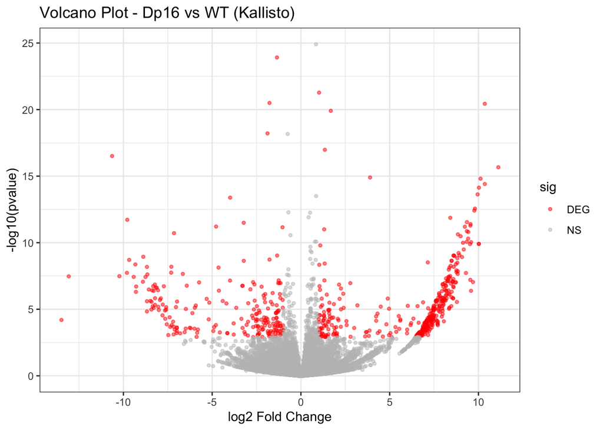

Volcano plot Kallisto

```r
res_kallisto$sig <- ifelse(!is.na(res_kallisto$padj) & res_kallisto$padj < 0.05 & abs(res_kallisto$log2FoldChange) > 1, "DEG", "NS")
ggplot(res_kallisto, aes(x=log2FoldChange, y=-log10(pvalue), color=sig)) +
  geom_point(alpha=0.5, size=1) +
  scale_color_manual(values=c("DEG"="red","NS"="grey")) +
  theme_bw() +
  labs(title="Volcano Plot - Dp16 vs WT (Kallisto)", x="log2 Fold Change", y="-log10(pvalue)")
```

## 2. Análisis Funcional (GSEA - GO)

```r
gsea <- read.csv("/Users/dubsirubs/Desktop/RNAseq_Equipo4/results_final/GSEA_GO_results.csv")
gsea_sig <- gsea[!is.na(gsea$pvalue) & gsea$pvalue < 0.05, ]
cat("Términos GO enriquecidos:", nrow(gsea_sig), "\n")
```

```
## Términos GO enriquecidos: 26
```

### Dotplot GSEA

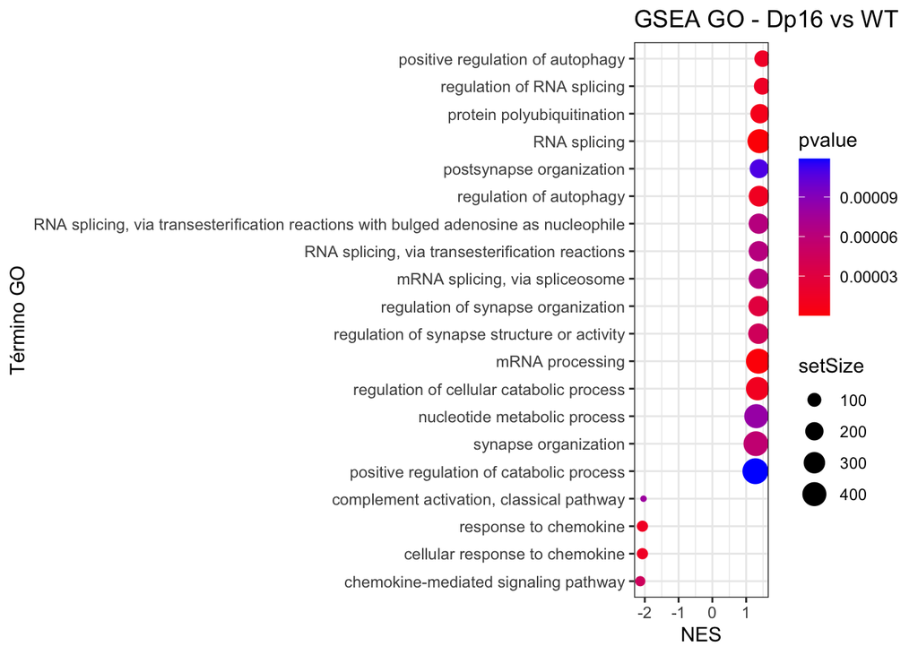

GSEA GO Biological Process

```r
top_gsea <- head(gsea_sig[order(gsea_sig$pvalue), ], 20)
ggplot(top_gsea, aes(x=NES, y=reorder(Description, NES), size=setSize, color=pvalue)) +
  geom_point() +
  scale_color_gradient(low="red", high="blue") +
  theme_bw() +
  labs(title="GSEA GO - Dp16 vs WT", x="NES", y="Término GO")
```

### Tabla de términos enriquecidos

```r
kable(top_gsea[, c("Description","NES","pvalue","p.adjust")],
      caption="Top 20 términos GO enriquecidos") %>%
  kable_styling(bootstrap_options=c("striped","hover","condensed"), full_width=FALSE)
```

Top 20 términos GO enriquecidos

|  | Description | NES | pvalue | p.adjust |
| --- | --- | --- | --- | --- |
| 1 | RNA splicing | 1.394552 | 0.0000001 | 0.0007946 |
| 2 | mRNA processing | 1.363026 | 0.0000004 | 0.0012429 |
| 7 | protein polyubiquitination | 1.411163 | 0.0000085 | 0.0097721 |
| 9 | regulation of cellular catabolic process | 1.338767 | 0.0000117 | 0.0097721 |
| 8 | regulation of autophagy | 1.384340 | 0.0000120 | 0.0097721 |
| 3 | response to chemokine | -2.070142 | 0.0000139 | 0.0097721 |
| 4 | cellular response to chemokine | -2.070142 | 0.0000139 | 0.0097721 |
| 6 | regulation of RNA splicing | 1.479490 | 0.0000152 | 0.0097721 |
| 5 | positive regulation of autophagy | 1.486275 | 0.0000155 | 0.0097721 |
| 10 | regulation of synapse organization | 1.369705 | 0.0000289 | 0.0163863 |
| 12 | regulation of synapse structure or activity | 1.364004 | 0.0000446 | 0.0216316 |
| 11 | chemokine-mediated signaling pathway | -2.134954 | 0.0000458 | 0.0216316 |
| 16 | synapse organization | 1.288906 | 0.0000570 | 0.0225825 |
| 13 | RNA splicing, via transesterification reactions | 1.373670 | 0.0000637 | 0.0225825 |
| 14 | RNA splicing, via transesterification reactions with bulged adenosine as nucleophile | 1.373670 | 0.0000637 | 0.0225825 |
| 15 | mRNA splicing, via spliceosome | 1.373670 | 0.0000637 | 0.0225825 |
| 17 | complement activation, classical pathway | -2.037787 | 0.0000790 | 0.0257577 |
| 18 | nucleotide metabolic process | 1.300575 | 0.0000818 | 0.0257577 |
| 19 | postsynapse organization | 1.385283 | 0.0001089 | 0.0324798 |
| 22 | positive regulation of catabolic process | 1.273702 | 0.0001190 | 0.0332507 |

## 3. Conclusiones

1. Se identificaron **781 transcritos** diferencialmente expresados con Kallisto y **363 genes** con STAR (padj < 0.05).
2. Entre los genes más significativos destacan genes relacionados con metabolismo hepático como **Apoa4, Papss2, Ces1g**, consistente con el fenotipo metabólico reportado en ratones Dp16.
3. El análisis GSEA identificó **26 términos GO** enriquecidos, incluyendo procesos de splicing de RNA, respuesta a quimiocinas y autofagia, sugiriendo alteraciones en el procesamiento del transcriptoma en el contexto de trisomía 21.

*Análisis realizado en el cluster ken.lavis.unam.mx. Equipo 4 - RNAseq 2026*